# Quantified Grad Student

Derek Nedveck

# What I’m going to present

- Intro - why did I do this
- data collection - what kind of data did I gather
- analysis
- future directions - other questions?

# Motivation

- entering grad school - how much time do I need to invest
- anecdotal: it will take all of your time

# But, who am I?

Grad student in Plant Biology - Genomics (computational work), and local adaptation (field / greenhouse / lab work) - How do I compare to other Grad students? - I’m probably not very representative… but then what is a “normal” grad student?

# Questions

- How much time do I invest in Grad School?
- how much time do I spend on campus?
- how much time am I working on grad school stuff?
- What percent of time that I am on campus am I actually getting work done?

# Data Collection

Data collected - Time doing work - Time I’m on campus

Tools: - Android App: Gleeo - Google Spreadsheet on my phone

# But how do I split my time up?

How many categories? - for a week, I tracked everything in a spreadsheet to get a sense of what I was doing - then, from that I tried to come up with categories to partition the tasks in the most meaningful way, with the least amount going into a “misc” bin - I’m still thinking about how best to partition my time, and am likely going to implement another scheme for the fall semester (starting September)

# Tracked time breakdown

Tracked time as “Projects”, with task subset - general; checking email, misc stuff, and admin work - reading; reading articles and books - seminar; sitting in department / research seminars - meeting; meeting for projects, meeting with people about my thesis - service; aka outreach - hacking; doing fun stuff that benefits my grad school work (time tracking work, work on my website, tooling around in Linux) - planning; capturing everything that I need to do GTD-style, and putting it in my calendar

# Categories, cont.

- funding; applying for funding, either for academic support, or research funding
- thesis; work towards my thesis – written prelims, oral exam, writing disseration, etc.
- MtHap; my RA work – genomics, also it pays the bills
- rhizpop; main thesis work, this involved field, greenhouse, and lab work
- TA; (in the future), TA prep, sitting in lecutre, and then office hours / student help

# Analysis

# How long am I at campus?

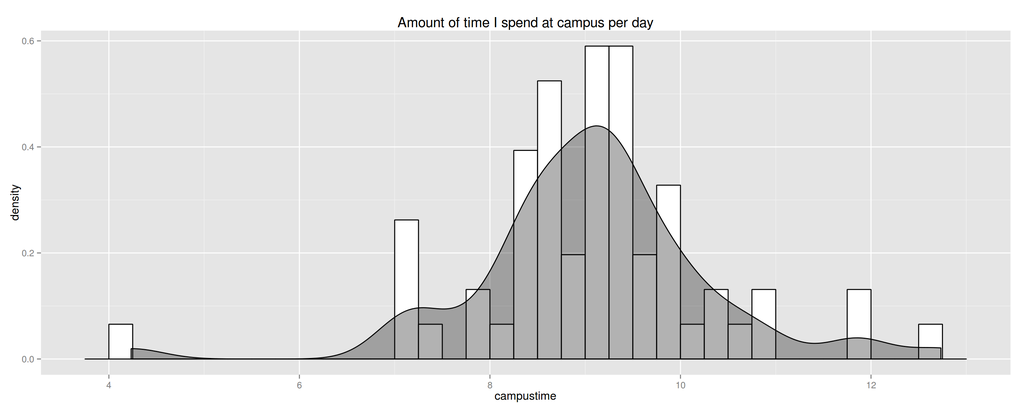

```
##  Min.  Mean  Max.
##  4.23  9.08 12.70
```

# Grouped by weekday?

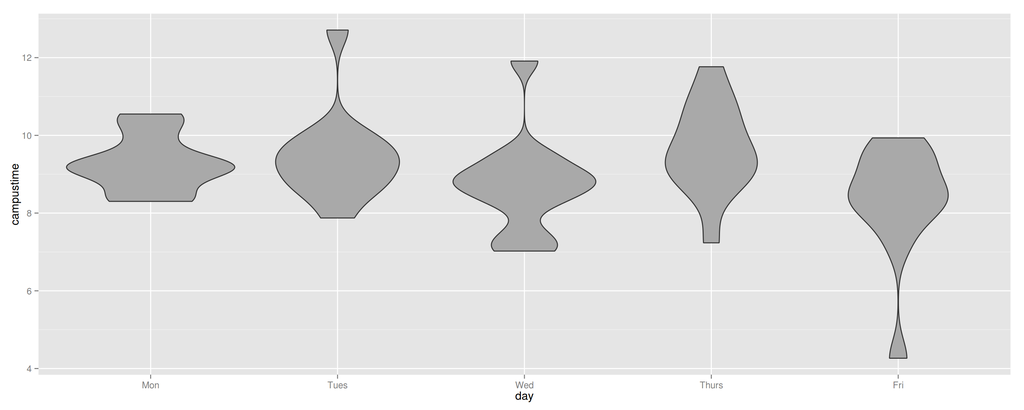

# Week

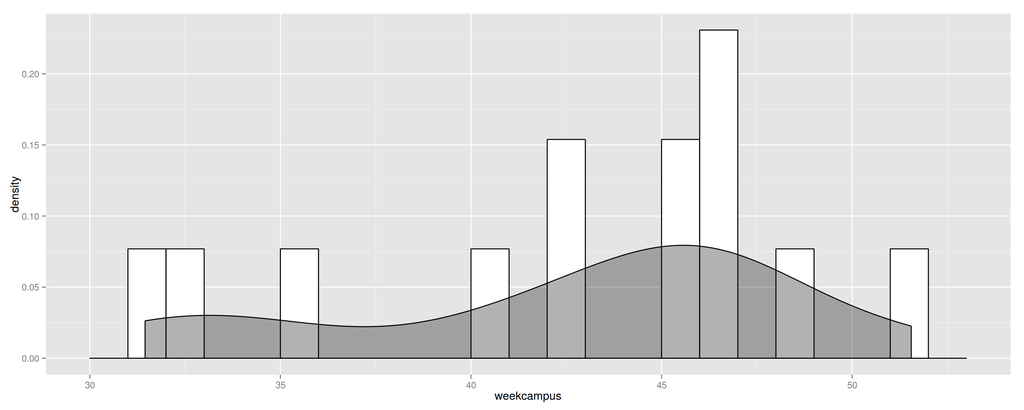

```
## Min. Mean Max.
## 31.4 42.6 51.6
```

# In Summary

I spend a mean of **9.08 hrs per day**, and **42.6 hrs per week** at campus

Day:

```
##  Min.  Mean  Max.
##  4.23  9.08 12.70
```

Week:

```
## Min. Mean Max.
## 31.4 42.6 51.6
```

# Future work

More questions, more data – which are worth my time in pursuing? - Rescuetime seems easy to implement and yield more data on what I am doing when I am working on a computer - How much do I read? - time tracking data gets at this, but how many articles do I read? - I store my notes in markdown files, but this misses the ones that I read for my prelim (I read them, incorporated and cited them, without taking down notes)

- I want to get more “Deep Thought” time in (a la Cal Newport), what kind of metrics can I measure to view this
- what kind of metrics reflect success in Grad School?
- I’ve measured time in grad schol to get a sense of how much I am investing, but what can I measure to actually improve what I am doing?

# Want more R?

TCRUG - Twin Cities R User Group meeting this Thursday, at 6:30pm on East Bank UMn